# Modelo con un regresor

# 1 Introducción

Vamos a leer el archivo de datos *kidiq.csv*:

```r
d = read.csv("datos/kidiq.csv")
str(d)
```

```
## 'data.frame':    434 obs. of  5 variables:
##  $ kid_score: int  65 98 85 83 115 98 69 106 102 95 ...
##  $ mom_hs   : int  1 1 1 1 1 0 1 1 1 1 ...
##  $ mom_iq   : num  121.1 89.4 115.4 99.4 92.7 ...
##  $ mom_work : int  4 4 4 3 4 1 4 3 1 1 ...
##  $ mom_age  : int  27 25 27 25 27 18 20 23 24 19 ...
```

donde se recogen datos de las siguientes variables:

- **kid_score** : puntuacion de un test cognitivo en niños de 3-4 años
- **mom_hs** :
  - mom_hs = 1 : las madres han terminado secundaria (high school)
  - mom_hs = 0 : las madres no terminaron secundaria
- **mom_iq** : puntuación de la madre en otro test cognitivo
- **mom_work** :
  - mom_work = 1 : la madre no trabajó en los primeros tres años del niño
  - mom_work = 2 : la madre trabajó en el segundo o tercer año
  - mom_work = 3 : la madre trabajó a tiempo parcial el primer año
  - mom_work = 4 : la madre trabajó a tiempo completo el primer año
- **mom_age** : edad de la madre

Estamos interesados en estudiar si la puntuación obtenida por los niños (variable *kid_score*) está relacionada con la puntuación obtenida por las madres (*mom_iq*). Primero dibujamos el gráfico de dispersión:

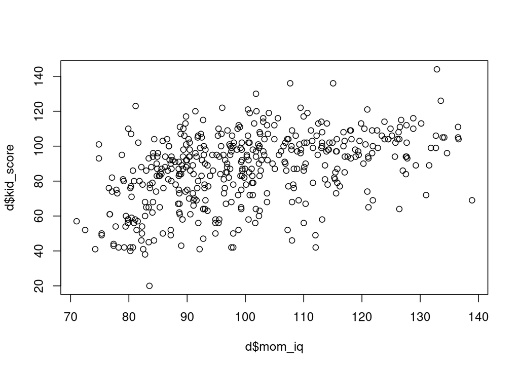

```r
plot(d$mom_iq, d$kid_score)
```

Como se observa, en términos generales cuando mayor es la puntuación obtenida por las madres mayor es la puntuación de los niños.

# 2 Ecuación del modelo

El modelo más sencillo que relaciona ambas variables es el modelo lineal:

$$kid\_score_i = \beta_0 + \beta_1 mom\_iq_i, \ i = 1,2,\cdots,n$$

Es la ecuación de una recta. Sin embargo, es imposible calcular una recta que pase por todos los puntos del gráfico. Otra posibilidad es utilizar el modelo:

$$kid\_score_i = \beta_0 + \beta_1 mom\_iq_i + e_i, \ i = 1,2,\cdots,n$$

es decir, se incluye el término $e_i$ que modele la diferencia entre el valor observado en $kid\_score_i$ y el valor que toma la recta en ese punto ($b_0 + b_1 mom\_iq_i$).

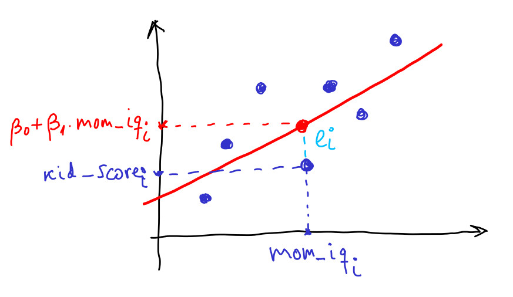

Estos términos se denominan **residuos**, y se definen como:

$$e_i = kid\_score_i - (\beta_0 + \beta_1 mom\_iq_i), \ i = 1,2,\cdots,n$$

# 3 Notación matricial del modelo

El modelo anterior se denomina **modelo de regresión lineal con un regresor**. De forma genérica se puede escribir así:

$$kid\_score_i = \beta_0 + \beta_1 mom\_iq_i + e_i, \ i = 1,2,\cdots,n$$

Si escribimos la ecuación para todos los datos disponibles:

$$i = 1 \Rightarrow kid\_score_1 = \beta_0 + \beta_1 mom\_iq_1 + e_1$$

$$i = 2 \Rightarrow kid\_score_2 = \beta_0 + \beta_1 mom\_iq_2 + e_2$$

$$\cdots$$

$$i = n \Rightarrow kid\_score_n = \beta_0 + \beta_1 mom\_iq_n + e_n$$

Agrupando:

$$\begin{bmatrix}
kid\_score_1 \\ kid\_score_2 \\ \cdots \\ kid\_score_n
\end{bmatrix}
=
\begin{bmatrix}
1 & mom\_iq_1 \\
1 & mom\_iq_2 \\
\cdots &\cdots \\
1 & mom\_iq_n \\
\end{bmatrix}
\begin{bmatrix}
\beta_0 \\ \beta_1
\end{bmatrix}
+
\begin{bmatrix}
e_1 \\ e_2 \\ \cdots \\ e_n
\end{bmatrix}$$

Finalmente, en notación matricial:

$$y = X \beta + e$$

donde $\beta$ es el vector de parámetros:

$$\beta
=
\begin{bmatrix}
\beta_0 \\ \beta_1
\end{bmatrix}$$

# 4 Estimación del modelo usando mínimos cuadrados

El modelo propuesto depende de dos parámetros, $\beta_0$ y $\beta_1$, que son desconocidos. Existen diferentes métodos para calcular dichos parámetros, entre ellos, el método de mínimos cuadrados. Este método consiste en calcular el valor del vector $\beta$ que minimiza la suma de los residuos al cuadrado (RSS, *residuals sum of squares*):

$$RSS = \sum e_i^2 = e^T e = (y - X \beta)^T(y - X \beta) = RSS(\beta)$$

Desarrollando el producto:

$$RSS(\beta) = y^T y - y^T X \beta - \beta^T X^T y + \beta^T X^T X \beta$$

Para calcular el mínimo se deriva respecto a $\beta$ y se iguala a cero (ver Apendice)

$$\frac{d RSS(\beta)}{d \beta} = - X^T y - X^T y + (X^T X + X^T X) \beta = 0$$

$$\beta = (X^TX)^{-1}X^Ty$$

# 5 Datos, modelo y residuos

Los datos disponibles son

$$\{ kid\_score_i, \ mom\_iq_{i}\}, \ i = 1,\cdots,n$$

Esos datos los modelamos utilizando la ecuación:

$$kid\_score_i = \beta_0 + \beta_1 mom\_iq_i + e_i, \ i = 1,2,\cdots,n$$

Es decir, para una madre dada $mom\_iq_i$, dividimos la puntuación de su hijo $kid\_score_i$ en dos partes: la parte que corresponde a la recta $b_0 + b_1 mom\_iq_i$ y los residuos $e_i$. La parte correspondiente a la recta se puede representar matricialmente como:

$$\hat y = X \beta$$

donde $\hat y = [\hat y_1 \ \hat y_2 \ \cdots \ \hat y_n]^T$. Por tanto los residuos se pueden calcular como

$$e_i = y_i - \hat y_i, \ i = 1,2,\ldots,n$$

o en forma matricial

$$e = y - \hat y$$

# 6 Aplicacion a los datos del ejemplo

- Matrices del modelo

```r
y = matrix(d$kid_score, ncol = 1)
head(y)
```

```
##      [,1]
## [1,]   65
## [2,]   98
## [3,]   85
## [4,]   83
## [5,]  115
## [6,]   98
```

```r
n = nrow(d)
X = cbind(rep(1,n), d$mom_iq)
head(X)
```

```
##      [,1]      [,2]
## [1,]    1 121.11753
## [2,]    1  89.36188
## [3,]    1 115.44316
## [4,]    1  99.44964
## [5,]    1  92.74571
## [6,]    1 107.90184
```

- Estimacion

```r
Xt_X = t(X) %*% X
Xt_y = t(X) %*% y
( beta = solve(Xt_X) %*% Xt_y )
```

```
##            [,1]
## [1,] 25.7997778
## [2,]  0.6099746
```

- valores de la recta

```r
y_e = X %*% beta
```

Estos valores se pueden representar

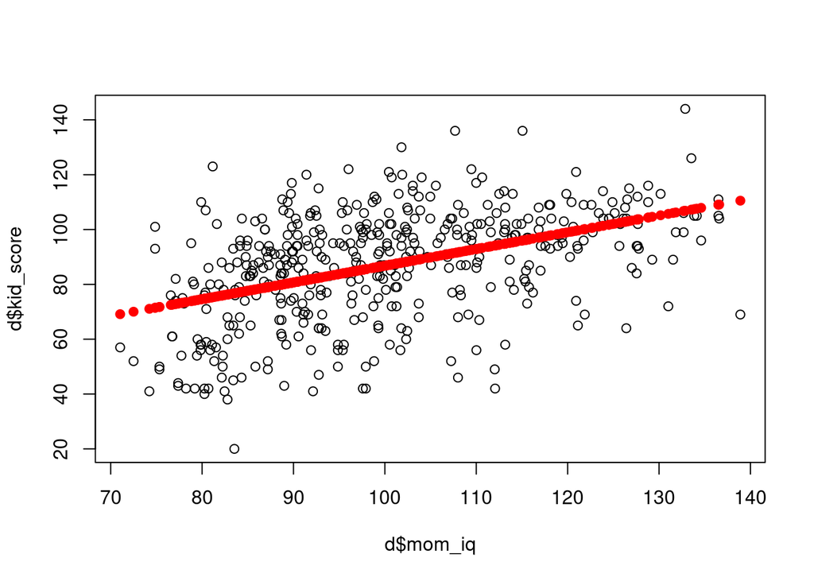

```r
plot(d$mom_iq, d$kid_score)
points(d$mom_iq, y_e, col = "red", pch = 19)
```

Finalmente, los residuos se calculan haciendo

```r
e = y - y_e
```

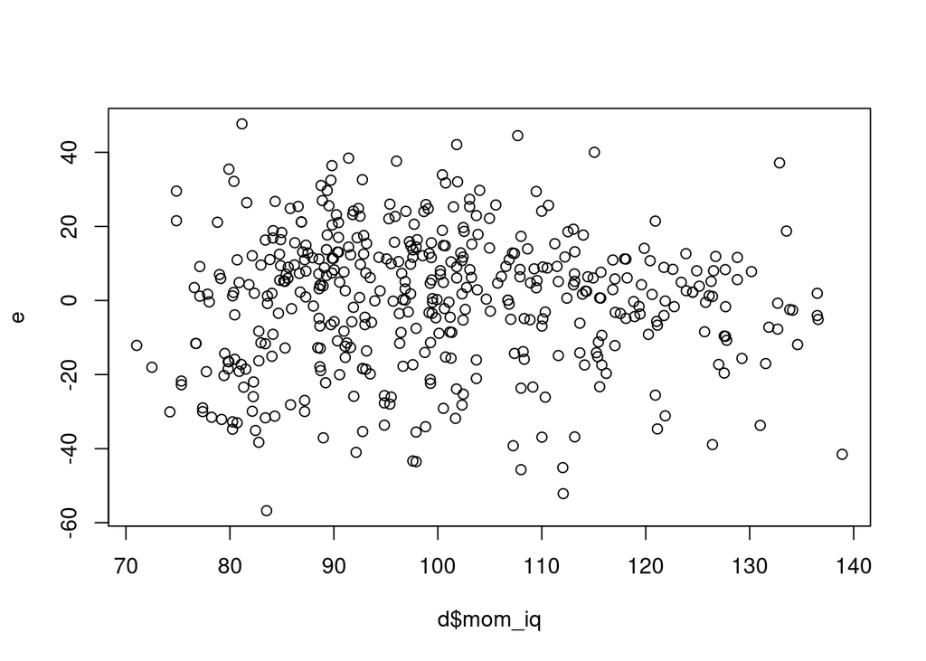

```r
plot(d$mom_iq, e)
```

# 7 Bondad del modelo ajustado

Es conveniente medir como de bueno es el ajuste del modelo. Una posibilidad es usar la suma de los residuos al cuadrado o RSS:

```r
(RSS = sum(e^2))
```

```
## [1] 144137.3
```

Pero esta variable depende de las unidades de x e y. Por tanto es difícil saber si un RSS alto indica que el modelo es bueno o malo. Lo ideal es utilizar variables adimensionales. La manera mas usual es utilizar el coeficiente de determinación o $R^2$:

$$R^2 = 1 - \frac{RSS}{TSS}$$

donde TSS es la suma total de cuadrados

$$TSS = \sum(y_i - \bar y)^2$$

```r
(TSS = sum((y-mean(y))^2))
```

```
## [1] 180386.2
```

```r
(R2 = 1 - RSS/TSS)
```

```
## [1] 0.2009512
```

El coeficiente $R^2$ toma valores entre cero y uno.

La suma total de cuadrados de *y* está relacionado con su varianza, ya que

$$s_y^2 = \frac{ \sum(y_i - \bar y)^2}{n-1} \Rightarrow TSS = (n-1)s_y^2$$

```r
(n-1)*var(y)
```

```
##          [,1]
## [1,] 180386.2
```